# Problem Set 4

Author

Luke Viter

Published

November 19, 2026

## **GitHub Repository:** https://github.com/lukeviter/ec422_ps4_viter.git

## ARIMA vs. ETS

```r
library(tidyverse)
library(fpp3)
library(BVAR)
```

**2.1**

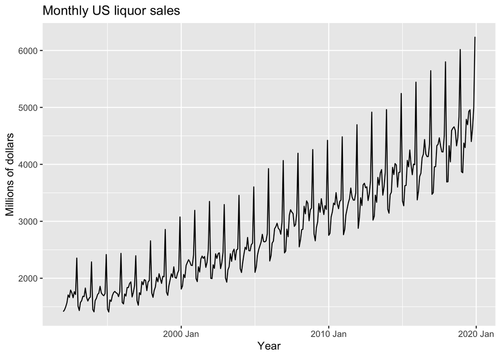

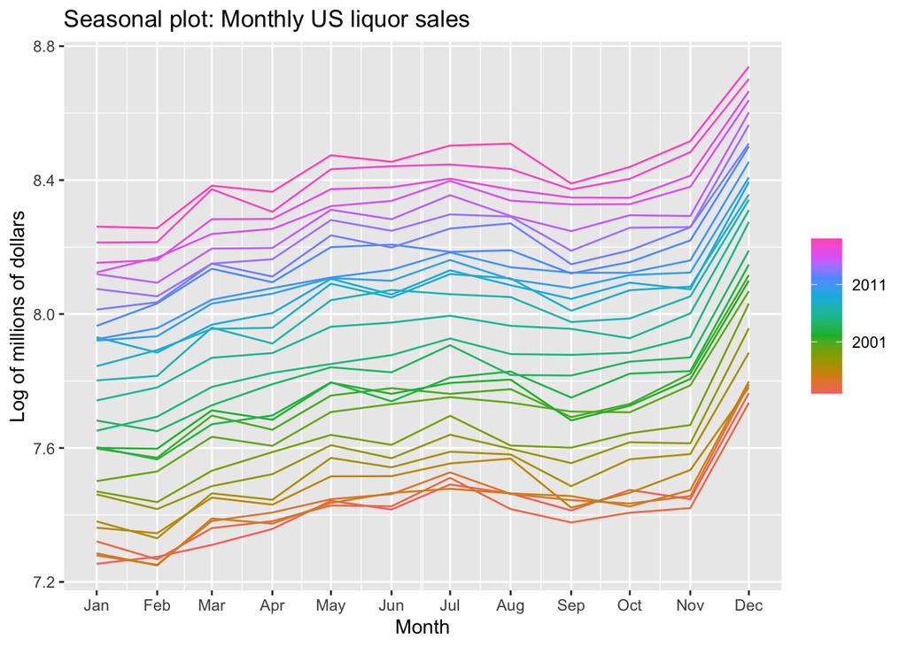

There is a definite upward trend to the data, with the size of the monthly swing increasing steadily as time progresses. This suggests that logs could be a good tool to stabilize the data. In the seasonal plot, the summer months as well as December seem to be peaks, while winter and fall are generally lower.

**2.2**

The ARIMA model selected is an ARIMA(1, 0, 2)(2,1, 1)[12] model, meaning the series is differenced once at the seasonal interval to try and achieve stationarity, but not at the regular interval.

The ETS model selected is an ETS(A, A, A) model, meaning it has additive error, additive trend, and additive seasonality.

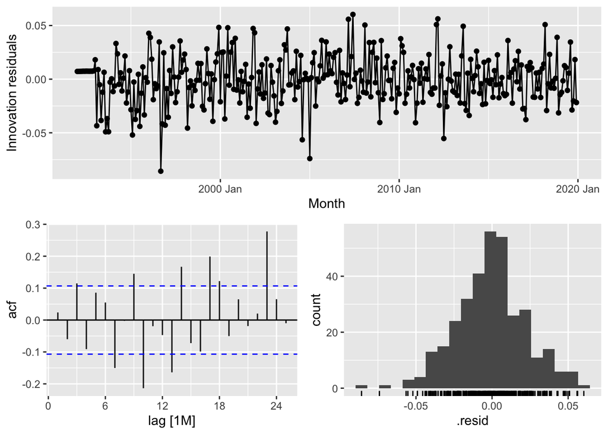

```
# A tibble: 1 × 3
  .model lb_stat lb_pvalue
  <chr>    <dbl>     <dbl>
1 arima     120.         0
```

The residuals do not look like white noise, and we reject the null hypothesis of no autocorrelation in the Ljung-Box test.

**2.3**

```r
liquor_cv_fc <- readRDS("results/liquor_cv_fit.rds")

accuracy(liquor_cv_fc) |>
  knitr::kable(digits = 2)
```

| .id | .model | .type | ME | RMSE | MAE | MPE | MAPE | MASE | RMSSE | ACF1 |
| --- | --- | --- | --- | --- | --- | --- | --- | --- | --- | --- |
| 1 | snaive | Training | 71.29 | 106.94 | 86.58 | 3.42 | 4.31 | 1.00 | 1.00 | 0.48 |
| 1 | ets | Training | 4.02 | 49.25 | 40.07 | 0.14 | 2.10 | 0.46 | 0.46 | -0.23 |
| 1 | arima | Training | 4.71 | 48.46 | 37.20 | 0.13 | 1.92 | 0.43 | 0.45 | 0.05 |
| 2 | snaive | Training | 70.67 | 106.45 | 85.83 | 3.39 | 4.28 | 1.00 | 1.00 | 0.47 |
| 2 | ets | Training | 5.06 | 49.63 | 40.09 | 0.22 | 2.10 | 0.47 | 0.47 | -0.27 |
| 2 | arima | Training | 3.97 | 48.69 | 37.44 | 0.09 | 1.93 | 0.44 | 0.46 | 0.02 |
| 3 | snaive | Training | 70.51 | 106.08 | 85.53 | 3.38 | 4.26 | 1.00 | 1.00 | 0.47 |
| 3 | ets | Training | 2.96 | 49.34 | 39.86 | 0.08 | 2.08 | 0.47 | 0.47 | -0.24 |
| 3 | arima | Training | 3.19 | 48.90 | 37.81 | 0.06 | 1.95 | 0.44 | 0.46 | 0.02 |
| 4 | snaive | Training | 70.19 | 105.66 | 85.07 | 3.37 | 4.24 | 1.00 | 1.00 | 0.47 |
| 4 | ets | Training | 6.61 | 49.14 | 39.42 | 0.29 | 2.06 | 0.46 | 0.47 | -0.22 |
| 4 | arima | Training | 3.17 | 48.69 | 37.52 | 0.06 | 1.94 | 0.44 | 0.46 | 0.02 |
| 5 | snaive | Training | 70.13 | 105.36 | 84.88 | 3.36 | 4.23 | 1.00 | 1.00 | 0.47 |
| 5 | ets | Training | 5.33 | 49.89 | 39.61 | 0.22 | 2.06 | 0.47 | 0.47 | -0.24 |
| 5 | arima | Training | 3.01 | 48.52 | 37.33 | 0.05 | 1.93 | 0.44 | 0.46 | 0.02 |
| 6 | snaive | Training | 70.33 | 105.25 | 84.95 | 3.37 | 4.22 | 1.00 | 1.00 | 0.47 |
| 6 | ets | Training | 2.10 | 50.38 | 40.02 | -0.01 | 2.08 | 0.47 | 0.48 | -0.20 |
| 6 | arima | Training | 3.15 | 48.34 | 37.17 | 0.06 | 1.92 | 0.44 | 0.46 | 0.03 |
| 7 | snaive | Training | 69.36 | 104.85 | 84.55 | 3.32 | 4.20 | 1.00 | 1.00 | 0.46 |
| 7 | ets | Training | 0.88 | 49.73 | 40.28 | -0.04 | 2.10 | 0.48 | 0.47 | -0.21 |
| 7 | arima | Training | 2.79 | 48.42 | 37.31 | 0.04 | 1.92 | 0.44 | 0.46 | 0.03 |
| 8 | snaive | Training | 69.43 | 104.65 | 84.50 | 3.32 | 4.19 | 1.00 | 1.00 | 0.45 |
| 8 | ets | Training | 1.01 | 49.48 | 40.05 | -0.03 | 2.08 | 0.47 | 0.47 | -0.25 |
| 8 | arima | Training | 2.32 | 48.42 | 37.40 | 0.02 | 1.92 | 0.44 | 0.46 | 0.03 |
| 9 | snaive | Training | 69.43 | 104.39 | 84.36 | 3.32 | 4.18 | 1.00 | 1.00 | 0.45 |
| 9 | ets | Training | 2.02 | 49.32 | 39.79 | 0.02 | 2.07 | 0.47 | 0.47 | -0.25 |
| 9 | arima | Training | 2.60 | 48.32 | 37.33 | 0.04 | 1.91 | 0.44 | 0.46 | 0.03 |
| 10 | snaive | Training | 68.66 | 103.96 | 83.82 | 3.28 | 4.15 | 1.00 | 1.00 | 0.45 |
| 10 | ets | Training | 3.35 | 50.39 | 41.17 | 0.15 | 2.13 | 0.49 | 0.48 | -0.29 |
| 10 | arima | Training | 1.88 | 47.85 | 36.55 | 0.00 | 1.87 | 0.44 | 0.46 | 0.04 |

[output cut: 618 more lines]

The first forecast is December of 2001, and the last forecast is November of 2019. According to the accuracy report, the ARIMA model forecasts more accurately.

**2.4**